# Project-FMST

```python
import warnings

warnings.filterwarnings("ignore")
# Libraries to help with reading and manipulating data
import pandas as pd
import numpy as np

# libaries to help with data visualization
%matplotlib inline
import matplotlib.pyplot as plt
import seaborn as sns

# Libraries to tune model, get different metric scores, and split data
from sklearn import metrics
from sklearn.model_selection import train_test_split, StratifiedKFold, cross_val_score
from sklearn.preprocessing import StandardScaler
from sklearn.model_selection import GridSearchCV, RandomizedSearchCV

from sklearn.impute import KNNImputer
from sklearn.pipeline import Pipeline, make_pipeline

#libraries to help with model building
from sklearn.linear_model import LogisticRegression
from sklearn.tree import DecisionTreeClassifier
from sklearn.ensemble import (
    AdaBoostClassifier,
    GradientBoostingClassifier,
    RandomForestClassifier)
from xgboost import XGBClassifier
```

## Load and view the dataset

```python
data = pd.read_csv('BankChurners.csv')
```

```python
data.head()
```

|  | CLIENTNUM | Attrition_Flag | Customer_Age | Gender | Dependent_count | Education_Level | Marital_Status | Income_Category | Card_Category | Months_on_book | ... | Months_Inactive_12_mon | Contacts_Count_12_mon | Credit_Limit | Total_Revolving_Bal | Avg_Open_To_Buy | Total_Amt_Chng_Q4_Q1 | Total_Trans_Amt | Total_Trans_Ct | Total_Ct_Chng_Q4_Q1 | Avg_Utilization_Ratio |
| --- | --- | --- | --- | --- | --- | --- | --- | --- | --- | --- | --- | --- | --- | --- | --- | --- | --- | --- | --- | --- | --- |
| 0 | 768805383 | Existing Customer | 45 | M | 3 | High School | Married | $60K - $80K | Blue | 39 | ... | 1 | 3 | 12691.0 | 777 | 11914.0 | 1.335 | 1144 | 42 | 1.625 | 0.061 |
| 1 | 818770008 | Existing Customer | 49 | F | 5 | Graduate | Single | Less than $40K | Blue | 44 | ... | 1 | 2 | 8256.0 | 864 | 7392.0 | 1.541 | 1291 | 33 | 3.714 | 0.105 |
| 2 | 713982108 | Existing Customer | 51 | M | 3 | Graduate | Married | $80K - $120K | Blue | 36 | ... | 1 | 0 | 3418.0 | 0 | 3418.0 | 2.594 | 1887 | 20 | 2.333 | 0.000 |
| 3 | 769911858 | Existing Customer | 40 | F | 4 | High School | Unknown | Less than $40K | Blue | 34 | ... | 4 | 1 | 3313.0 | 2517 | 796.0 | 1.405 | 1171 | 20 | 2.333 | 0.760 |
| 4 | 709106358 | Existing Customer | 40 | M | 3 | Uneducated | Married | $60K - $80K | Blue | 21 | ... | 1 | 0 | 4716.0 | 0 | 4716.0 | 2.175 | 816 | 28 | 2.500 | 0.000 |

5 rows × 21 columns

```python
data.info()
```

```
<class 'pandas.core.frame.DataFrame'>
RangeIndex: 10127 entries, 0 to 10126
Data columns (total 21 columns):
 #   Column                    Non-Null Count  Dtype
---  ------                    --------------  -----
 0   CLIENTNUM                 10127 non-null  int64
 1   Attrition_Flag            10127 non-null  object
 2   Customer_Age              10127 non-null  int64
 3   Gender                    10127 non-null  object
 4   Dependent_count           10127 non-null  int64
 5   Education_Level           10127 non-null  object
 6   Marital_Status            10127 non-null  object
 7   Income_Category           10127 non-null  object
 8   Card_Category             10127 non-null  object
 9   Months_on_book            10127 non-null  int64
 10  Total_Relationship_Count  10127 non-null  int64
 11  Months_Inactive_12_mon    10127 non-null  int64
 12  Contacts_Count_12_mon     10127 non-null  int64
 13  Credit_Limit              10127 non-null  float64
 14  Total_Revolving_Bal       10127 non-null  int64
 15  Avg_Open_To_Buy           10127 non-null  float64
 16  Total_Amt_Chng_Q4_Q1      10127 non-null  float64
 17  Total_Trans_Amt           10127 non-null  int64
 18  Total_Trans_Ct            10127 non-null  int64
 19  Total_Ct_Chng_Q4_Q1       10127 non-null  float64
 20  Avg_Utilization_Ratio     10127 non-null  float64
dtypes: float64(5), int64(10), object(6)
memory usage: 1.6+ MB
```

- There are total 21 columns and 10,127 observations in the dataset.
- We have bot integer and object variables.
- It doesn't show any missing value, but there are observations with "Unknown". They will be imputed later.

**Let's check the number of unique values in each column**

```python
data.nunique()
```

```
CLIENTNUM                   10127
Attrition_Flag                  2
Customer_Age                   45
Gender                          2
Dependent_count                 6
Education_Level                 7
Marital_Status                  4
Income_Category                 6
Card_Category                   4
Months_on_book                 44
Total_Relationship_Count        6
Months_Inactive_12_mon          7
Contacts_Count_12_mon           7
Credit_Limit                 6205
Total_Revolving_Bal          1974
Avg_Open_To_Buy              6813
Total_Amt_Chng_Q4_Q1         1158
Total_Trans_Amt              5033
Total_Trans_Ct                126
Total_Ct_Chng_Q4_Q1           830
Avg_Utilization_Ratio         964
dtype: int64
```

- We can drop the column - CLIENTNUM as it is unique for each customer and will not add value to the model.

```python
# Dropping columns - CLIENTNUM
data.drop(columns=["CLIENTNUM"], inplace=True)
```

**Summary of the data**

```python
data.describe().T
```

|  | count | mean | std | min | 25% | 50% | 75% | max |
| --- | --- | --- | --- | --- | --- | --- | --- | --- |
| Customer_Age | 10127.0 | 46.325960 | 8.016814 | 26.0 | 41.000 | 46.000 | 52.000 | 73.000 |
| Dependent_count | 10127.0 | 2.346203 | 1.298908 | 0.0 | 1.000 | 2.000 | 3.000 | 5.000 |
| Months_on_book | 10127.0 | 35.928409 | 7.986416 | 13.0 | 31.000 | 36.000 | 40.000 | 56.000 |
| Total_Relationship_Count | 10127.0 | 3.812580 | 1.554408 | 1.0 | 3.000 | 4.000 | 5.000 | 6.000 |
| Months_Inactive_12_mon | 10127.0 | 2.341167 | 1.010622 | 0.0 | 2.000 | 2.000 | 3.000 | 6.000 |
| Contacts_Count_12_mon | 10127.0 | 2.455317 | 1.106225 | 0.0 | 2.000 | 2.000 | 3.000 | 6.000 |
| Credit_Limit | 10127.0 | 8631.953698 | 9088.776650 | 1438.3 | 2555.000 | 4549.000 | 11067.500 | 34516.000 |
| Total_Revolving_Bal | 10127.0 | 1162.814061 | 814.987335 | 0.0 | 359.000 | 1276.000 | 1784.000 | 2517.000 |
| Avg_Open_To_Buy | 10127.0 | 7469.139637 | 9090.685324 | 3.0 | 1324.500 | 3474.000 | 9859.000 | 34516.000 |
| Total_Amt_Chng_Q4_Q1 | 10127.0 | 0.759941 | 0.219207 | 0.0 | 0.631 | 0.736 | 0.859 | 3.397 |
| Total_Trans_Amt | 10127.0 | 4404.086304 | 3397.129254 | 510.0 | 2155.500 | 3899.000 | 4741.000 | 18484.000 |
| Total_Trans_Ct | 10127.0 | 64.858695 | 23.472570 | 10.0 | 45.000 | 67.000 | 81.000 | 139.000 |
| Total_Ct_Chng_Q4_Q1 | 10127.0 | 0.712222 | 0.238086 | 0.0 | 0.582 | 0.702 | 0.818 | 3.714 |
| Avg_Utilization_Ratio | 10127.0 | 0.274894 | 0.275691 | 0.0 | 0.023 | 0.176 | 0.503 | 0.999 |

```python
data.describe(include=['object']).T
```

|  | count | unique | top | freq |
| --- | --- | --- | --- | --- |
| Attrition_Flag | 10127 | 2 | Existing Customer | 8500 |
| Gender | 10127 | 2 | F | 5358 |
| Education_Level | 10127 | 7 | Graduate | 3128 |
| Marital_Status | 10127 | 4 | Married | 4687 |
| Income_Category | 10127 | 6 | Less than $40K | 3561 |
| Card_Category | 10127 | 4 | Blue | 9436 |

**Let's check the count of each unique category in each of the categorical variables.**

```python
# Making a list of all categorical variables
cat_col = [
    "Attrition_Flag",
    "Gender",
    "Education_Level",
    "Marital_Status",
    "Income_Category",
    "Card_Category",
]

# Printing number of count of each unique value in each column
for column in cat_col:
    print(data[column].value_counts())
    print("-" * 40)
```

```
Existing Customer    8500
Attrited Customer    1627
Name: Attrition_Flag, dtype: int64
----------------------------------------
F    5358
M    4769
Name: Gender, dtype: int64
----------------------------------------
Graduate         3128
High School      2013
Unknown          1519
Uneducated       1487
College          1013
Post-Graduate     516
Doctorate         451
Name: Education_Level, dtype: int64
----------------------------------------
Married     4687
Single      3943
Unknown      749
Divorced     748
Name: Marital_Status, dtype: int64
----------------------------------------
Less than $40K    3561
$40K - $60K       1790
$80K - $120K      1535
$60K - $80K       1402
Unknown           1112
$120K +            727
Name: Income_Category, dtype: int64
----------------------------------------
Blue        9436
Silver       555
Gold         116
Platinum      20
Name: Card_Category, dtype: int64
----------------------------------------
```

- There is an imbalanced data on the feature Attribution_Flag in which majority of them are existing customers (8500 existing customers vs. 1627 attrited customers).
- Gender data are almost evenly distributed.
- In education level data, post graduate and doctorate are likely to be similar level of education. We can combine these two categories.
- There are 1519 Unknown education level, 749 Unknown marital status and 1112 Unknown income category. We will impute these unknown observations after splitting the data into train and test sets.

```python
# Replacing Post-Graduate with Doctorate
data["Education_Level"] = data["Education_Level"].replace("Post-Graduate", "Doctorate")
```

```python
# Replacing Unknown with NA
#data["Education_Level"] = data["Education_Level"].replace('Unknown', np.NaN)
#data["Marital_Status"] = data["Marital_Status"].replace("Unknown", "NAN")
#data["Income_Category"] = data["Income_Category"].replace("Unknown", "NAN")
```

```python
#pd.DataFrame(
#    data={
#        "% of Missing Values": round(data.isna().sum() / data.isna().count() * 100, 2)
#    }
#)
```

## EDA

### Univariate Analysis

```python
# While doing uni-variate analysis of numerical variables we want to study their central tendency
# and dispersion.
# Let us write a function that will help us create boxplot and histogram for any input numerical
# variable.
# This function takes the numerical column as the input and returns the boxplots
# and histograms for the variable.
# Let us see if this help us write faster and cleaner code.
def histogram_boxplot(feature, figsize=(15, 10), bins=None):
    """Boxplot and histogram combined
    feature: 1-d feature array
    figsize: size of fig (default (9,8))
    bins: number of bins (default None / auto)
    """
    f2, (ax_box2, ax_hist2) = plt.subplots(
        nrows=2,  # Number of rows of the subplot grid= 2
        sharex=True,  # x-axis will be shared among all subplots
        gridspec_kw={"height_ratios": (0.25, 0.75)},
        figsize=figsize,
    )  # creating the 2 subplots
    sns.boxplot(
        feature, ax=ax_box2, showmeans=True, color="violet"
    )  # boxplot will be created and a star will indicate the mean value of the column
    sns.distplot(
        feature, kde=F, ax=ax_hist2, bins=bins, palette="winter"
    ) if bins else sns.distplot(
        feature, kde=False, ax=ax_hist2
    )  # For histogram
    ax_hist2.axvline(
        np.mean(feature), color="green", linestyle="--"
    )  # Add mean to the histogram
    ax_hist2.axvline(
        np.median(feature), color="black", linestyle="-"
    )  # Add median to the histogram
```

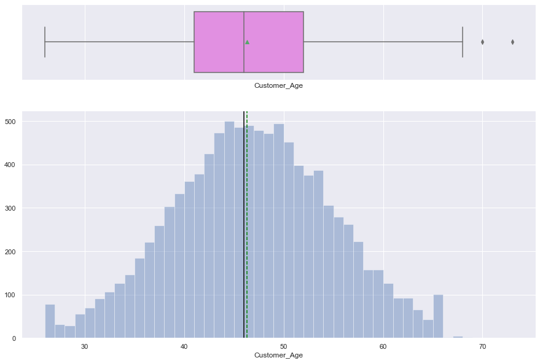

```python
# Observations on Customer_age
histogram_boxplot(data["Customer_Age"])
```

- There are couple of outliers in Customer_Age variable.
- It has a fairly normal distribution with almost equal mean and median.

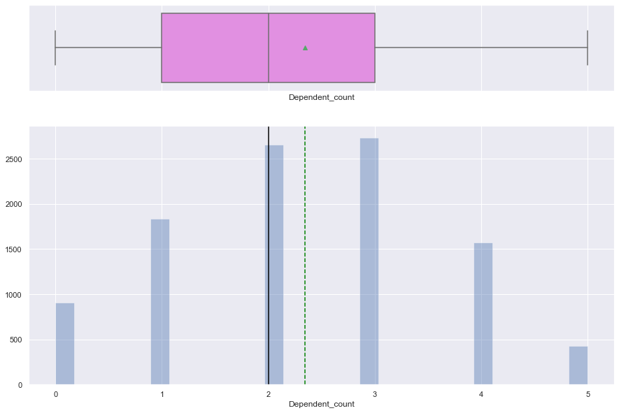

```python
# Observations on Dependent_count
histogram_boxplot(data["Dependent_count"])
```

- There is no outlier in 'Dependent_count' variable.
- It has very well distribution along with the customer data.

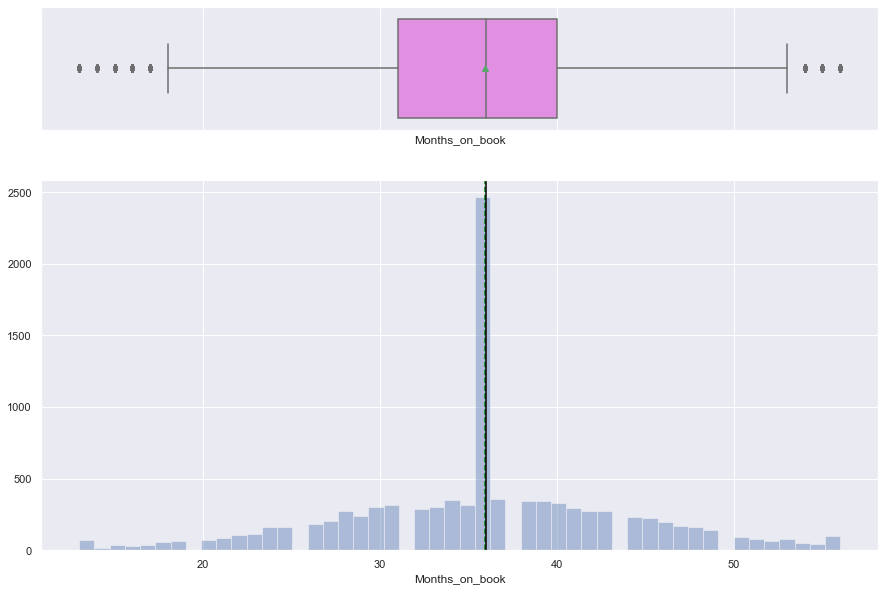

```python
# Observations on Months_on_book
histogram_boxplot(data["Months_on_book"])
```

- For 'Months_on_book' variable, we have highly skewed distributionon both sides with an approx. equal mean and median.
- It has also outliers on the both sides.
- Significant number of customers have at least 3 years of experience with the bank.

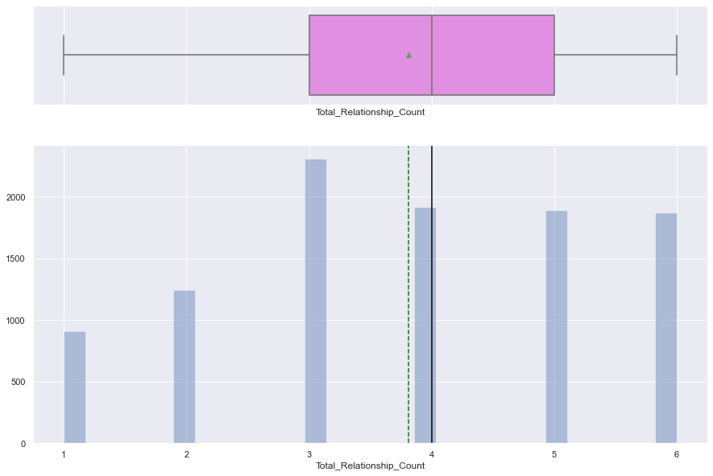

```python
# Observations on Total_Relationship_Count
histogram_boxplot(data["Total_Relationship_Count"])
```

- There is no outlier for 'Total_Relationship_Count' variable.
- There seems to be upward trend.
- Majority of customers are using 3 or more banking services.

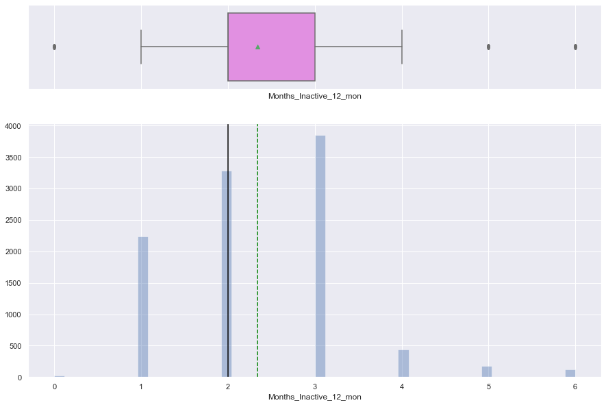

```python
# Observations on Months_Inactive_12_mon
histogram_boxplot(data["Months_Inactive_12_mon"])
```

- 'Months_Inactive_12_mon' variable has outliers on both sides.
- It has skewed to the right.
- Most of the customers' inactive period in the last 12 months is about 2 to 3 months.

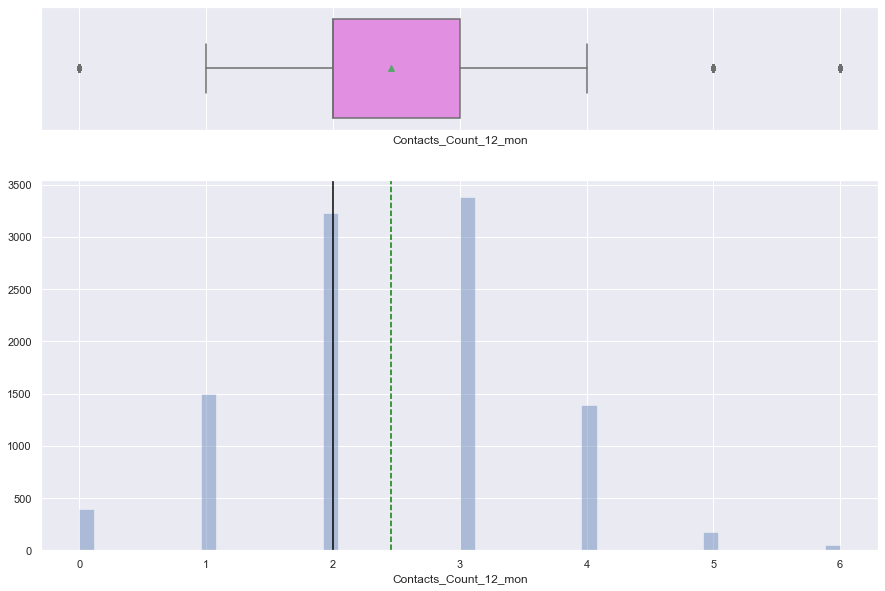

```python
# Observations on Contacts_Count_12_mon
histogram_boxplot(data["Contacts_Count_12_mon"])
```

- There are some outliers with 'Contacts_Count_12_mon' variable.
- It has almost a symmetric distribution having an avoidable right tail skew.

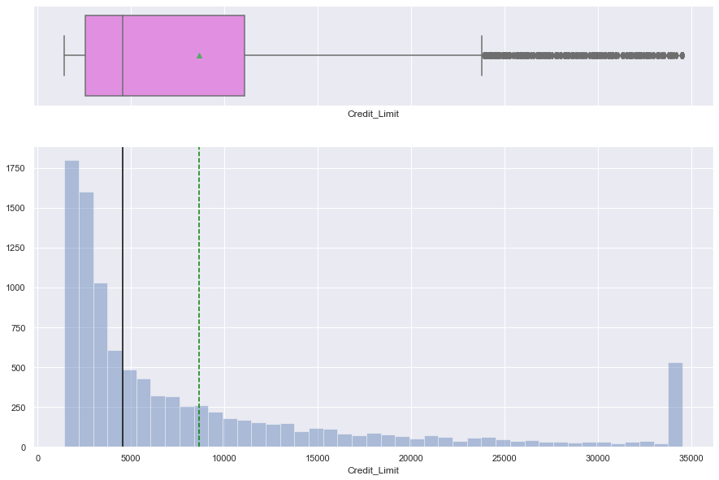

```python
# Observations on Credit_Limit
histogram_boxplot(data["Credit_Limit"])
```

- The distribution for credit limit is highly skewed to the right.
- Additionally, dedian of the distribution is less than 5,000. It means that more than 50 percent of customers have a credit limit of less than 5,000.
- There are many outliers on the right end of the boxplot. It is considered to be normal for credit limit for many different customer profile.

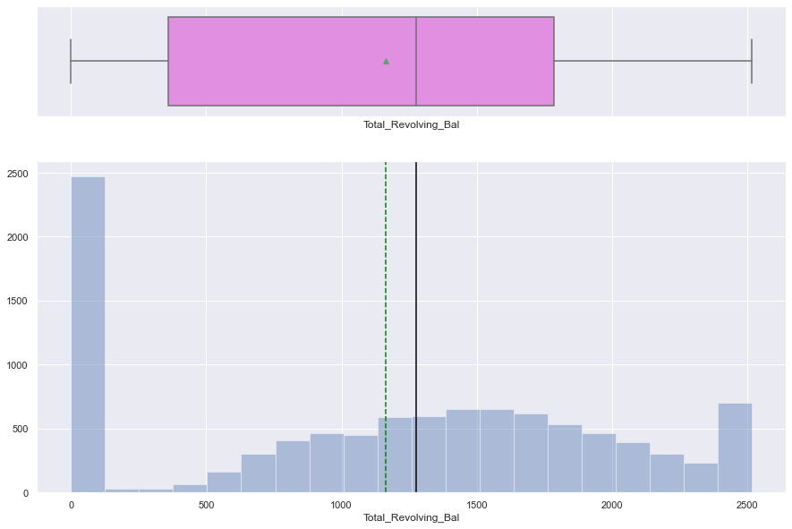

```python
# Observations on Total_Revolving_Bal
histogram_boxplot(data["Total_Revolving_Bal"])
```

- We have an abnormal data distribution here. Very high number of customers have total revolving balance closer to zero. The rest of the data seems evenly distributed.
- There is no outliers.

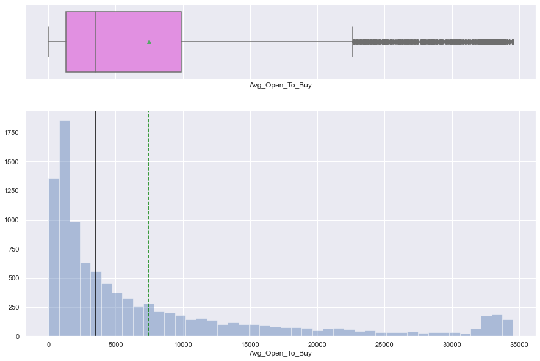

```python
# Observations on Avg_Open_To_Buy
histogram_boxplot(data["Avg_Open_To_Buy"])
```

- The distribution for 'Avg_Open_To_Buy' is highly skewed to the right.
- We can see that there are some extreme observations in the variable which can be considered as outliers as they very far from the rest of the values.
- It is not uncommon to have such distribution for 'Avg_Open_To_Buy' because we see above that more than 50% of the customers has 5,000 or less credit limit.

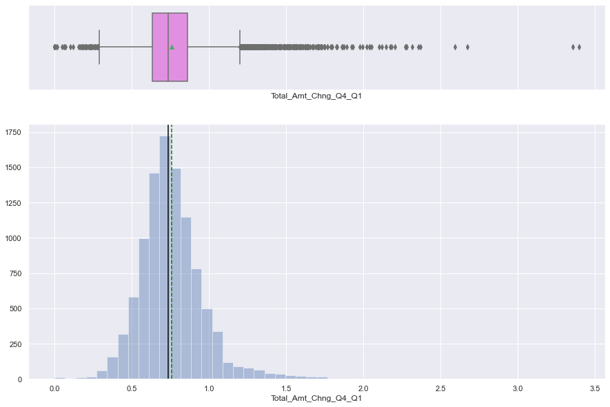

```python
# Observations on Total_Amt_Chng_Q4_Q1
histogram_boxplot(data["Total_Amt_Chng_Q4_Q1"])
```

- Although there are many outliers in the 'Total_Amt_Chng_Q4_Q1' variable, it is somewhat distributed symmetrically with approx. equal mean and median values.
- Yet, I would prefer capping some of the extreme values.
- Having a mean of about 0.75 means that transaction volume, in average, in the forth quarter is not as much as that in the first quarter.

```python
# Capping values for Total_Amt_Chng_Q4_Q1 at 2.5
data["Total_Amt_Chng_Q4_Q1"].clip(upper=2.5, inplace=True)
```

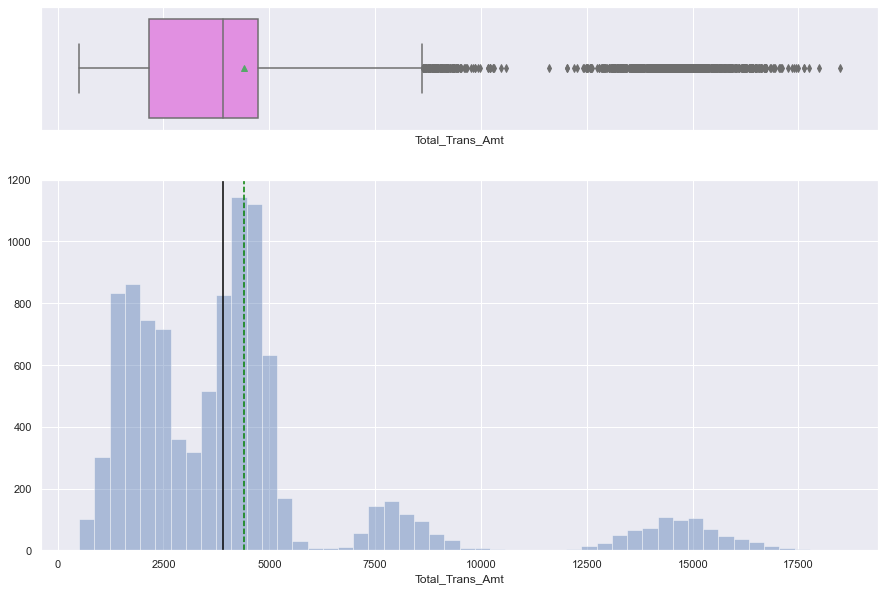

```python
# Observations on Total_Trans_Amt
histogram_boxplot(data["Total_Trans_Amt"])
```

- The distribution is highly skewed to the right.
- There are many outliers on the right side of the box plot.
- Observations mostly occur around 5,000 and lower level because many has a credit limit of 5,000 or less.

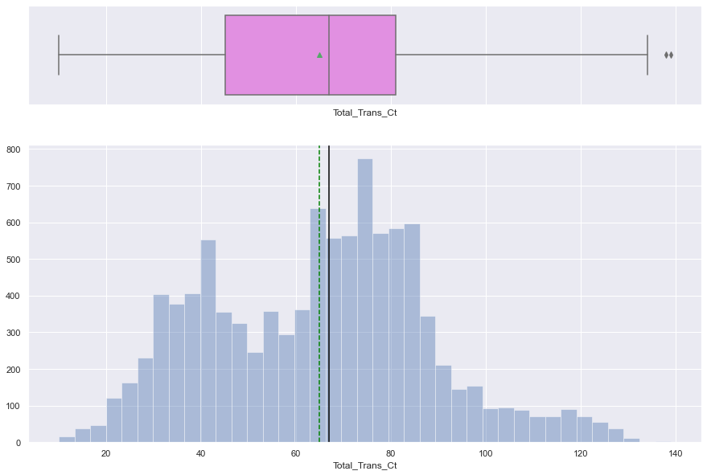

```python
# Observations on Total_Trans_Ct
histogram_boxplot(data["Total_Trans_Ct"])
```

- There are a few outliers in 'Total_Trans_Ct' variable.
- It is roughly distributed symmetrically.
- 'Total_Trans_Ct' variable has a mean and a median close to each other meaning that regardless of their credit limit or transaction amount, customers' average total transaction number in the last 12 month is about 70.

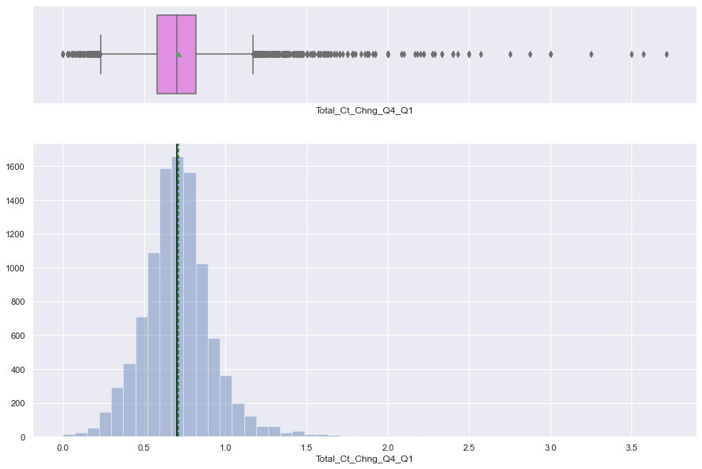

```python
# Observations on Total_Ct_Chng_Q4_Q1
histogram_boxplot(data["Total_Ct_Chng_Q4_Q1"])
```

- 'Total_Ct_Chng_Q4_Q1' variable has similar distribution to 'Total_Amt_Chng_Q4_Q1'.
- Although there are many outliers, it is distributed symmetrically with approx. equal mean and median values.
- Yet, I would prefer capping some of the extreme values.
- Having a mean of about 0.71 means that customers in average do not use their credit cards as much as they used in the first quarter.

```python
# Capping values for Total_Ct_Chng_Q4_Q1 at 2.5
data["Total_Ct_Chng_Q4_Q1"].clip(upper=2.5, inplace=True)
```

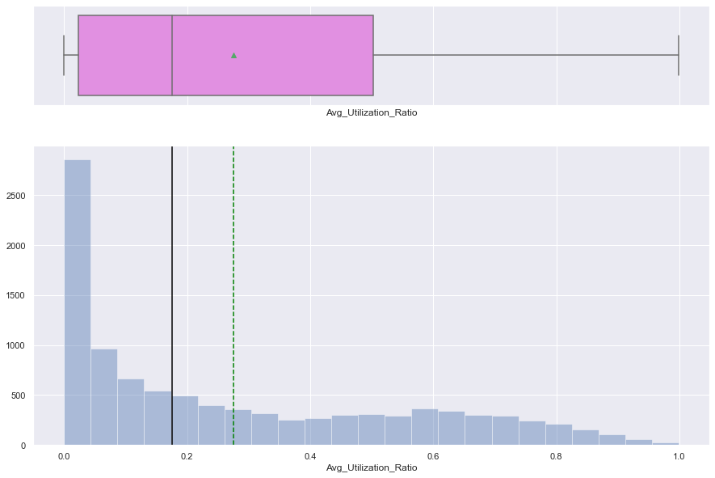

```python
# Observations on Avg_Utilization_Ratio
histogram_boxplot(data["Avg_Utilization_Ratio"])
```

- 'Avg_Utilization_Ratio' is highly skewed to the right.
- There is no outlier.
- Utilization ratio is mostly less than 30%; the histogram shows that most customers prefer not to rely only the credit cards.

```python
def perc_on_bar(feature):
    """
    plot
    feature: categorical feature
    the function won't work if a column is passed in hue parameter
    """
    # Creating a countplot for the feature
    sns.set(rc={"figure.figsize": (10, 5)})
    ax = sns.countplot(x=feature, data=data)

    total = len(feature)  # length of the column
    for p in ax.patches:
        percentage = "{:.1f}%".format(
            100 * p.get_height() / total
        )  # percentage of each class of the category
        x = p.get_x() + p.get_width() / 2 - 0.1  # width of the plot
        y = p.get_y() + p.get_height()  # hieght of the plot
        ax.annotate(percentage, (x, y), size=14)  # annotate the percantage

    plt.show()  # show the plot
```

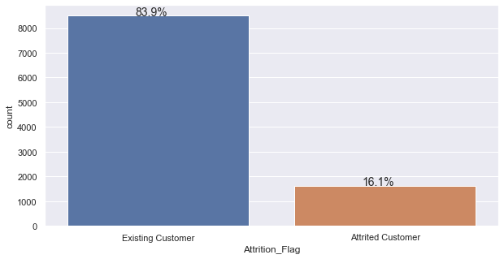

```python
# observations on Attrition_Flag
perc_on_bar(data["Attrition_Flag"])
```

- Almost 84% of the customers are currently existing customers in the data set.
- This shows that the distribuution of classes in the dependent variable is imbalanced. We have only about 16% observations where the customers are attritied.

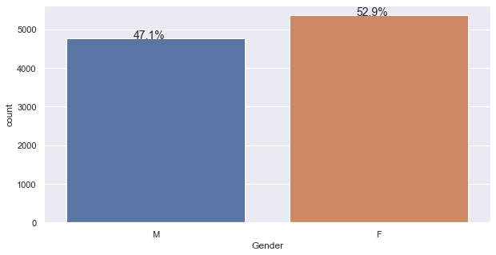

```python
# observations on Gender
perc_on_bar(data["Gender"])
```

- We have very close number of male and females in the dataset.

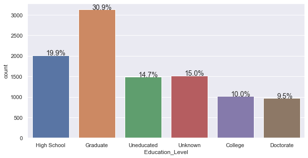

```python
# observations on Education_Level
perc_on_bar(data["Education_Level"])
```

- Graduate level customers are in the highest in the dataset.
- Uneducated customers are almost 15% of the data.
- Customers with college and doctorate degrees have approx. same percentage of the data.
- There are 15% missing (Unknown) observations which wil be imputed later below.

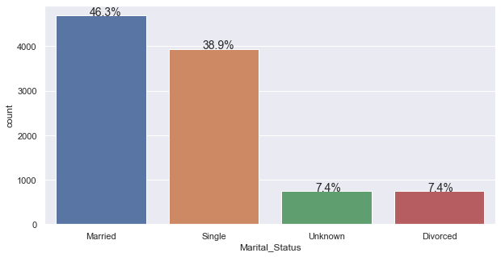

```python
# observations on Marital_Status
perc_on_bar(data["Marital_Status"])
```

- The data have many married as well as single customers, 46.3% and 38.9%, respectively.
- We have marital status 'Unknown' observations comprising 7.4% of the data which is also equal to 'Divorced' percentage.
- Unknown observation will be imputed later below.

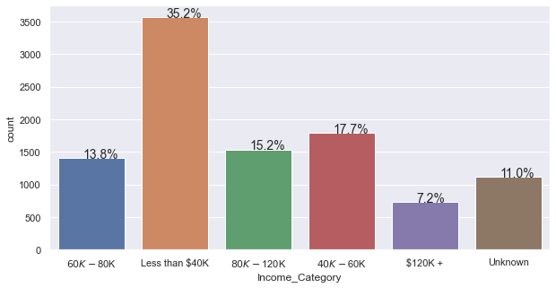

```python
# observations on Income_Category
perc_on_bar(data["Income_Category"])
```

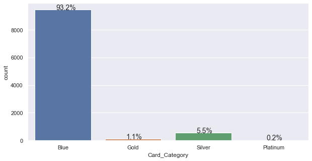

```python
# observations on Card_Category
perc_on_bar(data["Card_Category"])
```

- Approximately 93% of the customers use Blue category credit card.
- It makes sense because majority of customers' credit limit is less than 5,000.

### Bivariate Analysis

```python
# Replacing Existing Customer and Attrited Customer with 0 and 1, respectively.
data["Attrition_Flag"] = data["Attrition_Flag"].replace('Existing Customer', 0)
data["Attrition_Flag"] = data["Attrition_Flag"].replace('Attrited Customer', 1)
```

```python
data.head()
```

|  | Attrition_Flag | Customer_Age | Gender | Dependent_count | Education_Level | Marital_Status | Income_Category | Card_Category | Months_on_book | Total_Relationship_Count | Months_Inactive_12_mon | Contacts_Count_12_mon | Credit_Limit | Total_Revolving_Bal | Avg_Open_To_Buy | Total_Amt_Chng_Q4_Q1 | Total_Trans_Amt | Total_Trans_Ct | Total_Ct_Chng_Q4_Q1 | Avg_Utilization_Ratio |
| --- | --- | --- | --- | --- | --- | --- | --- | --- | --- | --- | --- | --- | --- | --- | --- | --- | --- | --- | --- | --- |
| 0 | 0 | 45 | M | 3 | High School | Married | $60K - $80K | Blue | 39 | 5 | 1 | 3 | 12691.0 | 777 | 11914.0 | 1.335 | 1144 | 42 | 1.625 | 0.061 |
| 1 | 0 | 49 | F | 5 | Graduate | Single | Less than $40K | Blue | 44 | 6 | 1 | 2 | 8256.0 | 864 | 7392.0 | 1.541 | 1291 | 33 | 2.500 | 0.105 |
| 2 | 0 | 51 | M | 3 | Graduate | Married | $80K - $120K | Blue | 36 | 4 | 1 | 0 | 3418.0 | 0 | 3418.0 | 2.500 | 1887 | 20 | 2.333 | 0.000 |
| 3 | 0 | 40 | F | 4 | High School | Unknown | Less than $40K | Blue | 34 | 3 | 4 | 1 | 3313.0 | 2517 | 796.0 | 1.405 | 1171 | 20 | 2.333 | 0.760 |
| 4 | 0 | 40 | M | 3 | Uneducated | Married | $60K - $80K | Blue | 21 | 5 | 1 | 0 | 4716.0 | 0 | 4716.0 | 2.175 | 816 | 28 | 2.500 | 0.000 |

```python
### Function to plot stacked bar charts for categorical columns
def stacked_plot(x):
    sns.set(palette="nipy_spectral")
    tab1 = pd.crosstab(x, data["Attrition_Flag"], margins=True)
    print(tab1)
    print("-" * 120)
    tab = pd.crosstab(x, data["Attrition_Flag"], normalize="index")
    tab.plot(kind="bar", stacked=True, figsize=(10, 5))
    plt.legend(loc="lower left", frameon=False)
    plt.legend(loc="upper left", bbox_to_anchor=(1, 1))
    plt.show()
```

```
Attrition_Flag     0     1    All
Gender
F               4428   930   5358
M               4072   697   4769
All             8500  1627  10127
------------------------------------------------------------------------------------------------------------------------
```

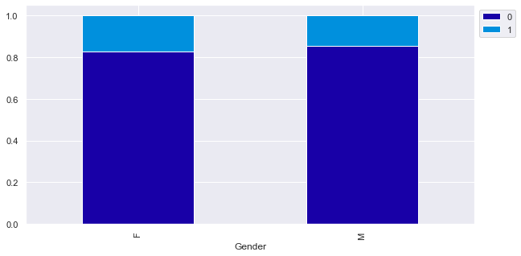

```python
stacked_plot(data["Gender"])
```

```
Attrition_Flag      0     1    All
Education_Level
College           859   154   1013
Doctorate         780   187    967
Graduate         2641   487   3128
High School      1707   306   2013
Uneducated       1250   237   1487
Unknown          1263   256   1519
All              8500  1627  10127
------------------------------------------------------------------------------------------------------------------------
```

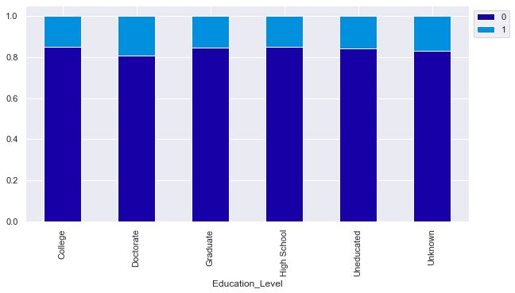

```python
stacked_plot(data["Education_Level"])
```

- Education level does not seem to be effective on closing accounts.
- Customers with doctorate level have slighthly more closed accounts.

```
Attrition_Flag     0     1    All
Marital_Status
Divorced         627   121    748
Married         3978   709   4687
Single          3275   668   3943
Unknown          620   129    749
All             8500  1627  10127
------------------------------------------------------------------------------------------------------------------------
```

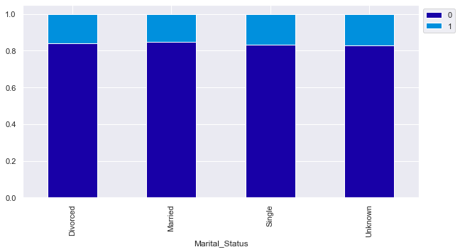

```python
stacked_plot(data["Marital_Status"])
```

-Marital status does not seem to be effective on closing the account.

```
Attrition_Flag      0     1    All
Income_Category
$120K +           601   126    727
$40K - $60K      1519   271   1790
$60K - $80K      1213   189   1402
$80K - $120K     1293   242   1535
Less than $40K   2949   612   3561
Unknown           925   187   1112
All              8500  1627  10127
------------------------------------------------------------------------------------------------------------------------
```

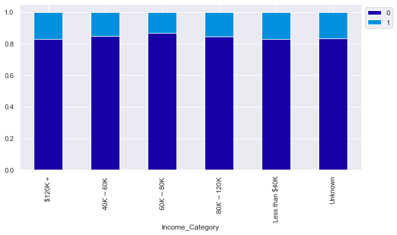

```python
stacked_plot(data["Income_Category"])
```

- It seems that customers income category with 60K-80K have less closed account that the other customers.

```
Attrition_Flag     0     1    All
Card_Category
Blue            7917  1519   9436
Gold              95    21    116
Platinum          15     5     20
Silver           473    82    555
All             8500  1627  10127
------------------------------------------------------------------------------------------------------------------------
```

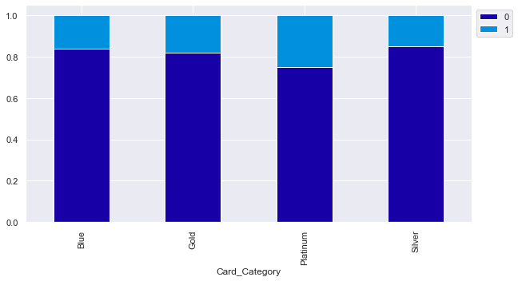

```python
stacked_plot(data["Card_Category"])
```

- Customers with Platinum credit cards have more closed accounts.
- Silver card holders have more open accounts compared the others.

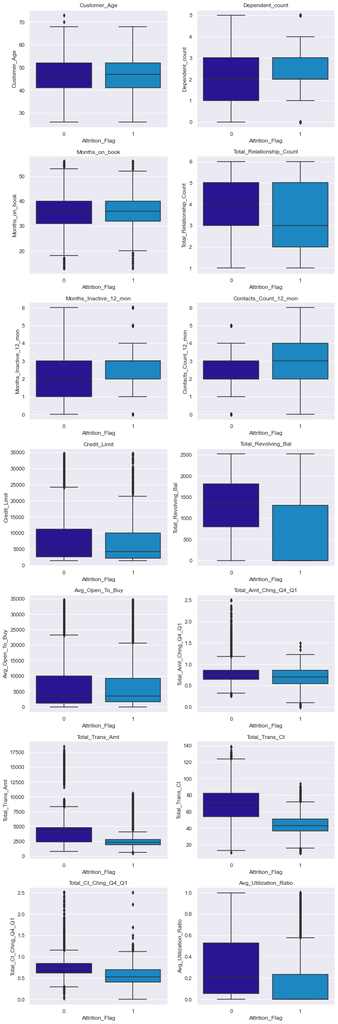

```python
cols = data[
    [
        "Customer_Age",
        "Dependent_count",
        "Months_on_book",
        "Total_Relationship_Count",
        "Months_Inactive_12_mon",
        "Contacts_Count_12_mon",
        "Credit_Limit",
        "Total_Revolving_Bal",
        "Avg_Open_To_Buy",
        "Total_Amt_Chng_Q4_Q1",
        "Total_Trans_Amt",
        "Total_Trans_Ct",
        "Total_Ct_Chng_Q4_Q1",
        "Avg_Utilization_Ratio"
    ]
].columns.tolist()
plt.figure(figsize=(10, 30))

for i, variable in enumerate(cols):
    plt.subplot(7,2, i + 1)
    sns.boxplot(data["Attrition_Flag"], data[variable])
    plt.tight_layout()
    plt.title(variable)
plt.show()
```

- Plots above show that total count change, average utilization ratio, total number of transaction, total transaction amount and total revolving balance variables are important indicators for customers in their decisions of whether to close the credit cards or not.
- As we see increases in those variables, they do not tend to close their accounts.

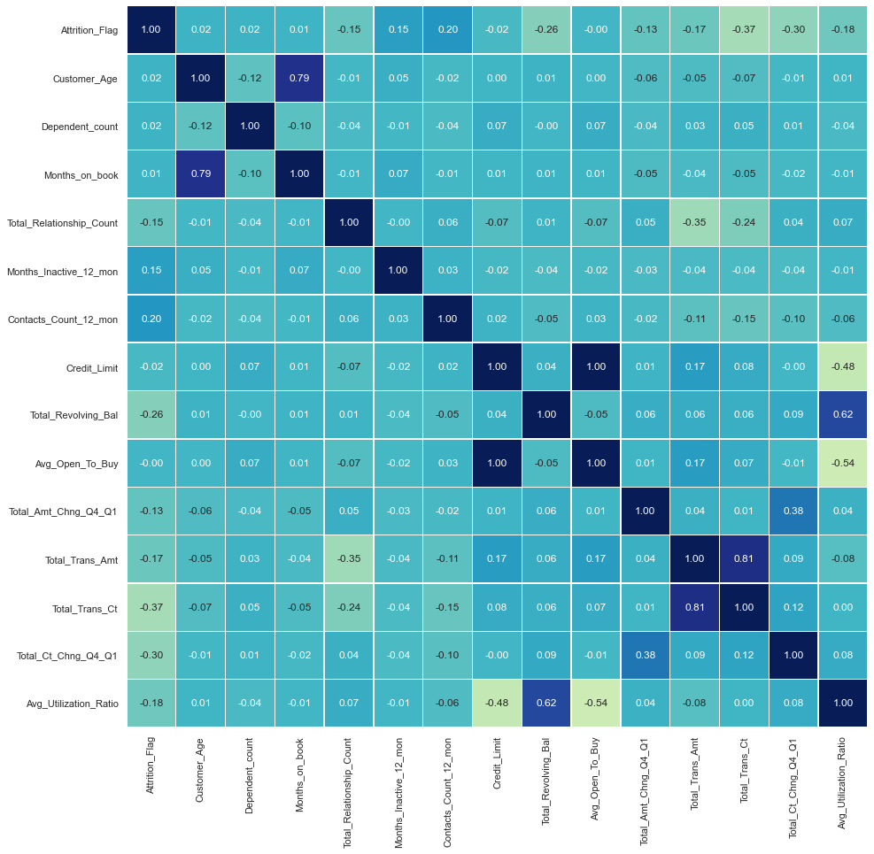

```python
sns.set(rc={"figure.figsize": (15, 15)})
sns.heatmap(
    data.corr(),
    annot=True,
    linewidths=0.5,
    center=0,
    cbar=False,
    cmap="YlGnBu",
    fmt="0.2f",
)
plt.show()
```

- Credit Limit and Average Open to Buy variables are perfectly positively correlated. Average Open to Buy variable can be dropped from the dataset.
- Total transaction count and Total Transaction Amount variables are highly correlated as well. Total Transaction Amount can be dropped from the dataset.
- Months on Book and Customer Age variables have a positive correlation (0.79).

## Data Preparation

```python
# Dropping the correlated variables
data.drop(columns=["Avg_Open_To_Buy", "Total_Trans_Amt"], inplace=True)
```

```python
# Replacing 'Unknown' observations with 'NaN'
data["Education_Level"] = data["Education_Level"].replace('Unknown', np.NaN)
data["Marital_Status"] = data["Marital_Status"].replace('Unknown', np.NaN)
data["Income_Category"] = data["Income_Category"].replace('Unknown', np.NaN)
```

**Missing Value Treatment**

- We will use KNN imputer to impute missing values.
- `KNNImputer`: Each sample's missing values are imputed by looking at the n_neighbors nearest neighbors found in the training set. Default value for n_neighbors=5.
- KNN imputer replaces missing values using the average of k nearest non-missing feature values.
- Nearest points are found based on euclidean distance

```python
pd.DataFrame(
    data={
        "% of Missing Values": round(data.isna().sum() / data.isna().count() * 100, 2)
    }
)
```

|  | % of Missing Values |
| --- | --- |
| Attrition_Flag | 0.00 |
| Customer_Age | 0.00 |
| Gender | 0.00 |
| Dependent_count | 0.00 |
| Education_Level | 15.00 |
| Marital_Status | 7.40 |
| Income_Category | 10.98 |
| Card_Category | 0.00 |
| Months_on_book | 0.00 |
| Total_Relationship_Count | 0.00 |
| Months_Inactive_12_mon | 0.00 |
| Contacts_Count_12_mon | 0.00 |
| Credit_Limit | 0.00 |
| Total_Revolving_Bal | 0.00 |
| Total_Amt_Chng_Q4_Q1 | 0.00 |
| Total_Trans_Ct | 0.00 |
| Total_Ct_Chng_Q4_Q1 | 0.00 |
| Avg_Utilization_Ratio | 0.00 |

```python
data.isnull().sum()
```

```
Attrition_Flag                 0
Customer_Age                   0
Gender                         0
Dependent_count                0
Education_Level             1519
Marital_Status               749
Income_Category             1112
Card_Category                  0
Months_on_book                 0
Total_Relationship_Count       0
Months_Inactive_12_mon         0
Contacts_Count_12_mon          0
Credit_Limit                   0
Total_Revolving_Bal            0
Total_Amt_Chng_Q4_Q1           0
Total_Trans_Ct                 0
Total_Ct_Chng_Q4_Q1            0
Avg_Utilization_Ratio          0
dtype: int64
```

```python
imputer = KNNImputer(n_neighbors=5)
```

```python
reqd_col_for_impute = ['Education_Level','Marital_Status','Income_Category']
```

```python
data[reqd_col_for_impute].head()
```

|  | Education_Level | Marital_Status | Income_Category |
| --- | --- | --- | --- |
| 0 | High School | Married | $60K - $80K |
| 1 | Graduate | Single | Less than $40K |
| 2 | Graduate | Married | $80K - $120K |
| 3 | High School | NaN | Less than $40K |
| 4 | Uneducated | Married | $60K - $80K |

```python
data1=data.copy()
```

```python
# we need to pass numerical values for each categorical column for KNN imputation so we will label encode them
Education_Level = {'Uneducated':0,'High School':1,'College':2, 'Graduate':3,'Doctorate':4}
data1['Education_Level'] = data1['Education_Level'].map(Education_Level)

Marital_Status = {'Divorced':0,'Single':1,'Married':2}
data1['Marital_Status'] = data1['Marital_Status'].map(Marital_Status)

Income_Category = {'Less than $40K':0,'$40K - $60K':1,'$60K - $80K':2, '$80K - $120K':3,'$120K +':4}
data1['Income_Category'] = data1['Income_Category'].map(Income_Category)
```

```python
data1.head()
```

|  | Attrition_Flag | Customer_Age | Gender | Dependent_count | Education_Level | Marital_Status | Income_Category | Card_Category | Months_on_book | Total_Relationship_Count | Months_Inactive_12_mon | Contacts_Count_12_mon | Credit_Limit | Total_Revolving_Bal | Total_Amt_Chng_Q4_Q1 | Total_Trans_Ct | Total_Ct_Chng_Q4_Q1 | Avg_Utilization_Ratio |
| --- | --- | --- | --- | --- | --- | --- | --- | --- | --- | --- | --- | --- | --- | --- | --- | --- | --- | --- |
| 0 | 0 | 45 | M | 3 | 1.0 | 2.0 | 2.0 | Blue | 39 | 5 | 1 | 3 | 12691.0 | 777 | 1.335 | 42 | 1.625 | 0.061 |
| 1 | 0 | 49 | F | 5 | 3.0 | 1.0 | 0.0 | Blue | 44 | 6 | 1 | 2 | 8256.0 | 864 | 1.541 | 33 | 2.500 | 0.105 |
| 2 | 0 | 51 | M | 3 | 3.0 | 2.0 | 3.0 | Blue | 36 | 4 | 1 | 0 | 3418.0 | 0 | 2.500 | 20 | 2.333 | 0.000 |
| 3 | 0 | 40 | F | 4 | 1.0 | NaN | 0.0 | Blue | 34 | 3 | 4 | 1 | 3313.0 | 2517 | 1.405 | 20 | 2.333 | 0.760 |
| 4 | 0 | 40 | M | 3 | 0.0 | 2.0 | 2.0 | Blue | 21 | 5 | 1 | 0 | 4716.0 | 0 | 2.175 | 28 | 2.500 | 0.000 |

- Values have been encoded.

### Split Data

```python
X = data1.drop(['Attrition_Flag'],axis=1)
y = data1['Attrition_Flag']
```

```python
# Splitting data into training and test set:
X_train, X_test, y_train, y_test = train_test_split(X, y, test_size=0.3, random_state=7,stratify=y)
print(X_train.shape, X_test.shape)
```

```
(7088, 17) (3039, 17)
```

**Imputing Missing Values**

```python
#Fit and transform the train data
X_train[reqd_col_for_impute]=imputer.fit_transform(X_train[reqd_col_for_impute])

#Transform the test data
X_test[reqd_col_for_impute]=imputer.transform(X_test[reqd_col_for_impute])
```

```python
#Checking that no column has missing values in train or test sets
print(X_train.isna().sum())
print('-'*30)
print(X_test.isna().sum())
```

```
Customer_Age                0
Gender                      0
Dependent_count             0
Education_Level             0
Marital_Status              0
Income_Category             0
Card_Category               0
Months_on_book              0
Total_Relationship_Count    0
Months_Inactive_12_mon      0
Contacts_Count_12_mon       0
Credit_Limit                0
Total_Revolving_Bal         0
Total_Amt_Chng_Q4_Q1        0
Total_Trans_Ct              0
Total_Ct_Chng_Q4_Q1         0
Avg_Utilization_Ratio       0
dtype: int64
------------------------------
Customer_Age                0
Gender                      0
Dependent_count             0
Education_Level             0
Marital_Status              0
Income_Category             0
Card_Category               0
Months_on_book              0
Total_Relationship_Count    0
Months_Inactive_12_mon      0
Contacts_Count_12_mon       0
Credit_Limit                0
Total_Revolving_Bal         0
Total_Amt_Chng_Q4_Q1        0
Total_Trans_Ct              0
Total_Ct_Chng_Q4_Q1         0
Avg_Utilization_Ratio       0
dtype: int64
```

- All missing values have been treated.
- Let's inverse map the encoded values.

```python
## Function to inverse the encoding
def inverse_mapping(x,y):
    inv_dict = {v: k for k, v in x.items()}
    X_train[y] = np.round(X_train[y]).map(inv_dict).astype('category')
    X_test[y] = np.round(X_test[y]).map(inv_dict).astype('category')
```

```python
inverse_mapping(Education_Level,'Education_Level')
inverse_mapping(Marital_Status,'Marital_Status')
inverse_mapping(Income_Category,'Income_Category')
```

- Checking inverse mapped values/categories.

```python
cols = X_train.select_dtypes(include=['object','category'])
for i in cols.columns:
    print(X_train[i].value_counts())
    print('*'*30)
```

```
F    3753
M    3335
Name: Gender, dtype: int64
Graduate       2272
College        1571
High School    1539
Uneducated     1032
Doctorate       674
Name: Education_Level, dtype: int64
Married     3470
Single      3080
Divorced     538
Name: Marital_Status, dtype: int64
Less than $40K    2489
$40K - $60K       1841
$60K - $80K       1147
$80K - $120K      1107
$120K +            504
Name: Income_Category, dtype: int64
Blue        6619
Silver       373
Gold          81
Platinum      15
Name: Card_Category, dtype: int64
```

```python
cols = X_test.select_dtypes(include=['object','category'])
for i in cols.columns:
    print(X_train[i].value_counts())
    print('*'*30)
```

```
F    3753
M    3335
Name: Gender, dtype: int64
Graduate       2272
College        1571
High School    1539
Uneducated     1032
Doctorate       674
Name: Education_Level, dtype: int64
Married     3470
Single      3080
Divorced     538
Name: Marital_Status, dtype: int64
Less than $40K    2489
$40K - $60K       1841
$60K - $80K       1147
$80K - $120K      1107
$120K +            504
Name: Income_Category, dtype: int64
Blue        6619
Silver       373
Gold          81
Platinum      15
Name: Card_Category, dtype: int64
```

- Inverse mapping returned original labels.

### Encoding categorical varaibles

```python
X_train=pd.get_dummies(X_train,drop_first=True)
X_test=pd.get_dummies(X_test,drop_first=True)
print(X_train.shape, X_test.shape)
```

```
(7088, 26) (3039, 26)
```

- After encoding there are 26 columns.

## Building the model

### Model evaluation criterion:

#### Model can make wrong predictions as:

1. Predicting a customer will leave the bank's credit card services but the customer doesn't leave - Loss of resources
2. Predicting a customer will not leave the bank's credit card services but the customer leave - Loss of opportunity

#### Which case is more important?

- Predicting a customer will not leave the bank's credit card services but the customer leave i.e. losing on a potential source of income for the company because that customer would not be targeted by the marketing team while, in fact, she should have been targeted.

#### How to reduce this loss i.e need to reduce False Negatives?

- Company wants Recall to be maximized, greater the Recall lesser the chances of false negatives.

```python
##  Function to calculate different metric scores of the model - Accuracy, Recall and Precision
def get_metrics_score(model,train,test,train_y,test_y,flag=True):
    '''
    model : classifier to predict values of X

    '''
    # defining an empty list to store train and test results
    score_list=[]

    pred_train = model.predict(train)
    pred_test = model.predict(test)

    train_acc = model.score(train,train_y)
    test_acc = model.score(test,test_y)

    train_recall = metrics.recall_score(train_y,pred_train)
    test_recall = metrics.recall_score(test_y,pred_test)

    train_precision = metrics.precision_score(train_y,pred_train)
    test_precision = metrics.precision_score(test_y,pred_test)

    score_list.extend((train_acc,test_acc,train_recall,test_recall,train_precision,test_precision))

    # If the flag is set to True then only the following print statements will be dispayed. The default value is set to True.
    if flag == True:
        print("Accuracy on training set : ",model.score(train,train_y))
        print("Accuracy on test set : ",model.score(test,test_y))
        print("Recall on training set : ",metrics.recall_score(train_y,pred_train))
        print("Recall on test set : ",metrics.recall_score(test_y,pred_test))
        print("Precision on training set : ",metrics.precision_score(train_y,pred_train))
        print("Precision on test set : ",metrics.precision_score(test_y,pred_test))

    return score_list # returning the list with train and test scores
```

```python
def make_confusion_matrix(model,y_actual,labels=[1, 0]):
    '''
    model : classifier to predict values of X
    y_actual : ground truth

    '''
    y_predict = model.predict(X_test)
    cm=metrics.confusion_matrix( y_actual, y_predict, labels=[0, 1])
    df_cm = pd.DataFrame(cm, index = [i for i in ["Actual - No","Actual - Yes"]],
                  columns = [i for i in ['Predicted - No','Predicted - Yes']])
    group_counts = ["{0:0.0f}".format(value) for value in
                cm.flatten()]
    group_percentages = ["{0:.2%}".format(value) for value in
                         cm.flatten()/np.sum(cm)]
    labels = [f"{v1}\n{v2}" for v1, v2 in
              zip(group_counts,group_percentages)]
    labels = np.asarray(labels).reshape(2,2)
    plt.figure(figsize = (10,7))
    sns.heatmap(df_cm, annot=labels,fmt='')
    plt.ylabel('True label')
    plt.xlabel('Predicted label')
```

### Logistic Regression

```python
lr = LogisticRegression(random_state=1)
lr.fit(X_train,y_train)
```

```
LogisticRegression(random_state=1)
```

**Let's evaluate the model performance by using KFold and cross_val_score**

- `K-Folds cross-validator` provides dataset indices to split data into train/validation sets. Split dataset into k consecutive stratified folds (without shuffling by default). Each fold is then used once as validation while the k - 1 remaining folds form the training set.

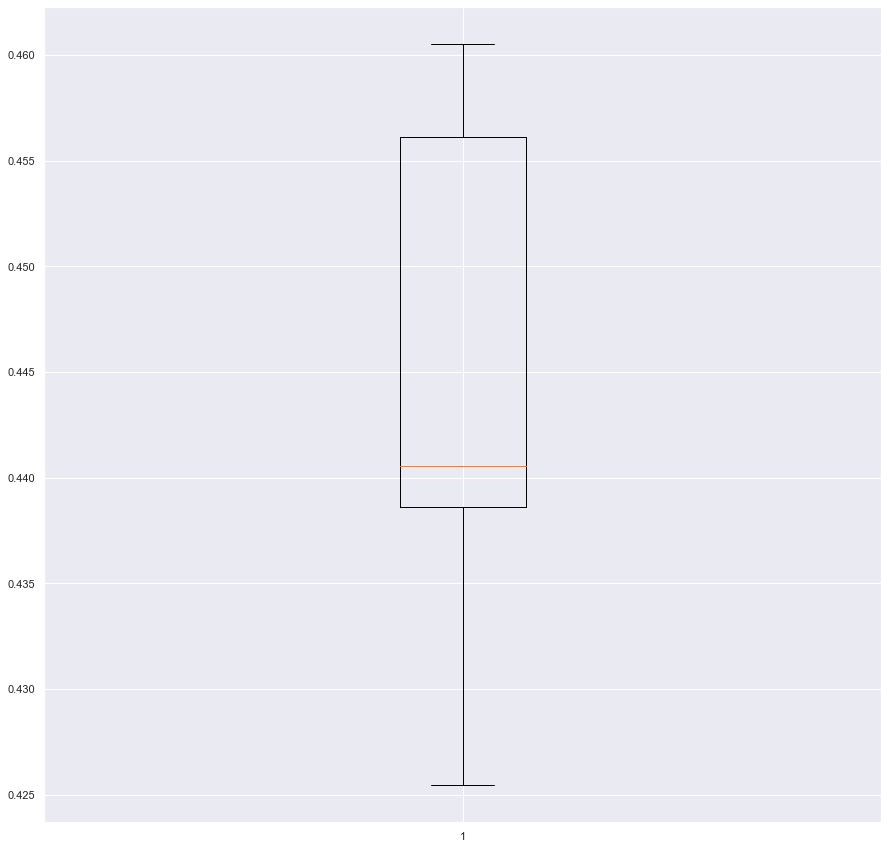

```python
scoring='recall'
kfold=StratifiedKFold(n_splits=5,shuffle=True,random_state=1)     #Setting number of splits equal to 5
cv_result_bfr=cross_val_score(estimator=lr, X=X_train, y=y_train, scoring=scoring, cv=kfold)
#Plotting boxplots for CV scores of model defined above
plt.boxplot(cv_result_bfr)
plt.show()
```

- Performance on training set varies between 0.425 to 0.46 recall.
- Let's check the performance on test data.

```
Accuracy on training set :  0.8872742663656885
Accuracy on test set :  0.8877920368542284
Recall on training set :  0.46093064091308167
Recall on test set :  0.45286885245901637
Precision on training set :  0.7394366197183099
Precision on test set :  0.7491525423728813
```

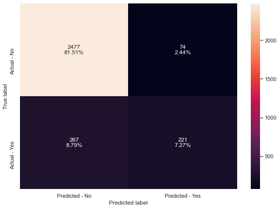

```python
#Calculating different metrics
scores_LR = get_metrics_score(lr,X_train,X_test,y_train,y_test)

# creating confusion matrix
make_confusion_matrix(lr,y_test)
```

- Logistic Regression has given a generalized performance on training and test set.
- Recall is very low, we can try oversampling (increase training data) to see if the model performance can be improved.

### Oversampling train data using SMOTE

```python
from imblearn.over_sampling import SMOTE
```

```python
print("Before UpSampling, counts of label 'Attrited Customer': {}".format(sum(y_train==1)))
print("Before UpSampling, counts of label 'Existing Customer': {} \n".format(sum(y_train==0)))

sm = SMOTE(sampling_strategy = 1 ,k_neighbors = 5, random_state=1)   #Synthetic Minority Over Sampling Technique
X_train_over, y_train_over = sm.fit_resample(X_train, y_train)


print("After UpSampling, counts of label 'Attrited Customer': {}".format(sum(y_train_over==1)))
print("After UpSampling, counts of label 'Existing Customer': {} \n".format(sum(y_train_over==0)))


print('After UpSampling, the shape of train_X: {}'.format(X_train_over.shape))
print('After UpSampling, the shape of train_y: {} \n'.format(y_train_over.shape))
```

```
Before UpSampling, counts of label 'Attrited Customer': 1139
Before UpSampling, counts of label 'Existing Customer': 5949

After UpSampling, counts of label 'Attrited Customer': 5949
After UpSampling, counts of label 'Existing Customer': 5949

After UpSampling, the shape of train_X: (11898, 26)
After UpSampling, the shape of train_y: (11898,)
```

### Logistic Regression on oversampled data

```python
log_reg_over = LogisticRegression(random_state = 1)

# Training the basic logistic regression model with training set
log_reg_over.fit(X_train_over,y_train_over)
```

```
LogisticRegression(random_state=1)
```

**Let's evaluate the model performance by using KFold and cross_val_score**

- `K-Folds cross-validator` provides dataset indices to split data into train/validation sets. Split dataset into k consecutive stratified folds (without shuffling by default). Each fold is then used once as validation while the k - 1 remaining folds form the training set.

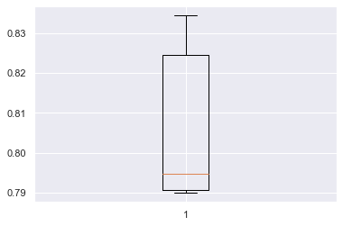

```python
scoring='recall'
kfold=StratifiedKFold(n_splits=5,shuffle=True,random_state=1)     #Setting number of splits equal to 5
cv_result_over=cross_val_score(estimator=log_reg_over, X=X_train_over, y=y_train_over, scoring=scoring, cv=kfold)
#Plotting boxplots for CV scores of model defined above
plt.boxplot(cv_result_over)
plt.show()
```

- Performance of model on training set varies between 0.79 to 0.84, which is an improvement from the previous model.
- Let's check the performance on the test set.

```
Accuracy on training set :  0.8093797276853253
Accuracy on test set :  0.8065153010858835
Recall on training set :  0.7945873256009414
Recall on test set :  0.7274590163934426
Precision on training set :  0.8188117096830071
Precision on test set :  0.4382716049382716
```

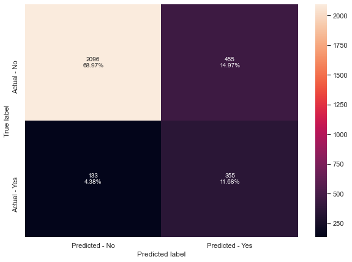

```python
#Calculating different metrics
get_metrics_score(log_reg_over,X_train_over,X_test,y_train_over,y_test)

# creating confusion matrix
make_confusion_matrix(log_reg_over,y_test)
```

```python
from imblearn.under_sampling import RandomUnderSampler
rus = RandomUnderSampler(random_state = 1)
X_train_un, y_train_un = rus.fit_resample(X_train, y_train)
```

```python
print("Before Under Sampling, counts of label 'Attrited Customer': {}".format(sum(y_train==1)))
print("Before Under Sampling, counts of label 'Existing Customer': {} \n".format(sum(y_train==0)))

print("After Under Sampling, counts of label 'Attrited Customer': {}".format(sum(y_train_un==1)))
print("After Under Sampling, counts of label 'Existing Customer': {} \n".format(sum(y_train_un==0)))

print('After Under Sampling, the shape of train_X: {}'.format(X_train_un.shape))
print('After Under Sampling, the shape of train_y: {} \n'.format(y_train_un.shape))
```

```
Before Under Sampling, counts of label 'Attrited Customer': 1139
Before Under Sampling, counts of label 'Existing Customer': 5949

After Under Sampling, counts of label 'Attrited Customer': 1139
After Under Sampling, counts of label 'Existing Customer': 1139

After Under Sampling, the shape of train_X: (2278, 26)
After Under Sampling, the shape of train_y: (2278,)
```

### Logistic Regression on undersampled data

```python
log_reg_under = LogisticRegression(random_state = 1)
log_reg_under.fit(X_train_un,y_train_un )
```

```
LogisticRegression(random_state=1)
```

**Let's evaluate the model performance by using KFold and cross_val_score**

- `K-Folds cross-validator` provides dataset indices to split data into train/validation sets. Split dataset into k consecutive stratified folds (without shuffling by default). Each fold is then used once as validation while the k - 1 remaining folds form the training set.

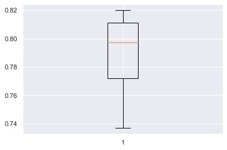

```python
scoring='recall'
kfold=StratifiedKFold(n_splits=5,shuffle=True,random_state=1)     #Setting number of splits equal to 5
cv_result_under=cross_val_score(estimator=log_reg_under, X=X_train_un, y=y_train_un, scoring=scoring, cv=kfold)
#Plotting boxplots for CV scores of model defined above
plt.boxplot(cv_result_under)
plt.show()
```

- Performance of model on training set varies between 0.74 to 0.82, which is an improvement from the initial model(without oversampling)
- Let's check the performance on the test set.

```
Accuracy on training set :  0.8015803336259877
Accuracy on test set :  0.7986179664363278
Recall on training set :  0.7954345917471466
Recall on test set :  0.7868852459016393
Precision on training set :  0.8053333333333333
Precision on test set :  0.4304932735426009
```

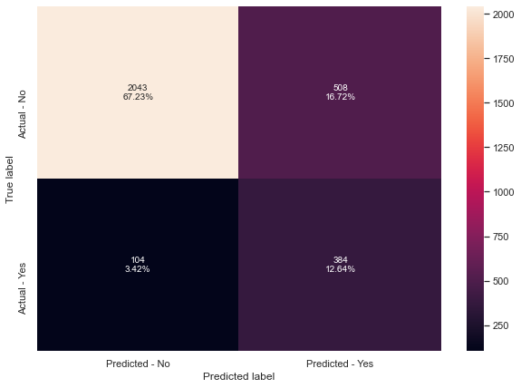

```python
#Calculating different metrics
get_metrics_score(log_reg_under,X_train_un,X_test,y_train_un,y_test)


# creating confusion matrix
make_confusion_matrix(log_reg_under,y_test)
```

- Downsampling gives us better results. Test set recall results improves better comparing to oversampling - 0.79 vs 0.73.
- Model gives a generalized performance on training and test set.
- Model performance has improved using downsampling - Logistic regression is now able to differentiate well between the two classes.

```python
# defining list of model
models = [lr]

# defining empty lists to add train and test results
acc_train = []
acc_test = []
recall_train = []
recall_test = []
precision_train = []
precision_test = []

# looping through all the models to get the metrics score - Accuracy, Recall and Precision
for model in models:

    j = get_metrics_score(model,X_train,X_test,y_train,y_test,False)
    acc_train.append(j[0])
    acc_test.append(j[1])
    recall_train.append(j[2])
    recall_test.append(j[3])
    precision_train.append(j[4])
    precision_test.append(j[5])
```

```python
# defining list of models
models = [log_reg_over]

# looping through all the models to get the metrics score - Accuracy, Recall and Precision
for model in models:

    j = get_metrics_score(model,X_train_over,X_test,y_train_over,y_test,False)
    acc_train.append(j[0])
    acc_test.append(j[1])
    recall_train.append(j[2])
    recall_test.append(j[3])
    precision_train.append(j[4])
    precision_test.append(j[5])
```

```python
# defining list of model
models = [log_reg_under]

# looping through all the models to get the metrics score - Accuracy, Recall and Precision
for model in models:

    j = get_metrics_score(model,X_train_un,X_test,y_train_un,y_test,False)
    acc_train.append(j[0])
    acc_test.append(j[1])
    recall_train.append(j[2])
    recall_test.append(j[3])
    precision_train.append(j[4])
    precision_test.append(j[5])
```

```python
comparison_frame = pd.DataFrame({'Model':['Logistic Regression','Logistic Regression on Oversampled data',
                                          'Logistic Regression on Undersampled data'],
                                          'Train_Accuracy': acc_train,'Test_Accuracy': acc_test,
                                          'Train_Recall':recall_train,'Test_Recall':recall_test,
                                          'Train_Precision':precision_train,'Test_Precision':precision_test})

#Sorting models in decreasing order of test recall
comparison_frame
```

|  | Model | Train_Accuracy | Test_Accuracy | Train_Recall | Test_Recall | Train_Precision | Test_Precision |
| --- | --- | --- | --- | --- | --- | --- | --- |
| 0 | Logistic Regression | 0.887274 | 0.887792 | 0.460931 | 0.452869 | 0.739437 | 0.749153 |
| 1 | Logistic Regression on Oversampled data | 0.809380 | 0.806515 | 0.794587 | 0.727459 | 0.818812 | 0.438272 |
| 2 | Logistic Regression on Undersampled data | 0.801580 | 0.798618 | 0.795435 | 0.786885 | 0.805333 | 0.430493 |

As it is shown that logistic regression model on undersampled data gives the best recall score.

## Bagging and Boosting

**Let's start by building different models using KFold and cross_val_score with pipelines and tune the best model using GridSearchCV and RandomizedSearchCV**

- `Stratified K-Folds cross-validator` provides dataset indices to split data in train/validation sets. Split dataset into k consecutive folds (without shuffling by default) keeping distribution of both classes in each fold same as the target variable. Each fold is then used once as a validation while the k - 1 remaining folds form the training set.

```python
models = []  # Empty list to store all the models

# Appending pipelines for each model into the list
models.append(
    (
        "LR",
        Pipeline(
            steps=[
                ("scaler", StandardScaler()),
                ("log_reg", LogisticRegression(random_state=1)),
            ]
        ),
    )
)
models.append(
    (
        "RF",
        Pipeline(
            steps=[
                ("scaler", StandardScaler()),
                ("random_forest", RandomForestClassifier(random_state=1)),
            ]
        ),
    )
)
models.append(
    (
        "GBM",
        Pipeline(
            steps=[
                ("scaler", StandardScaler()),
                ("gradient_boosting", GradientBoostingClassifier(random_state=1)),
            ]
        ),
    )
)
models.append(
    (
        "ADB",
        Pipeline(
            steps=[
                ("scaler", StandardScaler()),
                ("adaboost", AdaBoostClassifier(random_state=1)),
            ]
        ),
    )
)
models.append(
    (
        "XGB",
        Pipeline(
            steps=[
                ("scaler", StandardScaler()),
                ("xgboost", XGBClassifier(random_state=1,eval_metric='logloss')),
            ]
        ),
    )
)
models.append(
    (
        "DTREE",
        Pipeline(
            steps=[
                ("scaler", StandardScaler()),
                ("decision_tree", DecisionTreeClassifier(random_state=1)),
            ]
        ),
    )
)

results = []  # Empty list to store all model's CV scores
names = []  # Empty list to store name of the models

# loop through all models to get the mean cross validated score
for name, model in models:
    scoring = "recall"
    kfold = StratifiedKFold(
        n_splits=5, shuffle=True, random_state=1
    )  # Setting number of splits equal to 5
    cv_result = cross_val_score(
        estimator=model, X=X_train, y=y_train, scoring=scoring, cv=kfold
    )
    results.append(cv_result)
    names.append(name)
    print("{}: {}".format(name, cv_result.mean() * 100))
```

```
LR: 53.90640698662958
RF: 66.63575237653605
GBM: 70.67547723935388
ADB: 70.23649431949919
XGB: 73.8380091197156
DTREE: 68.74372053481721
```

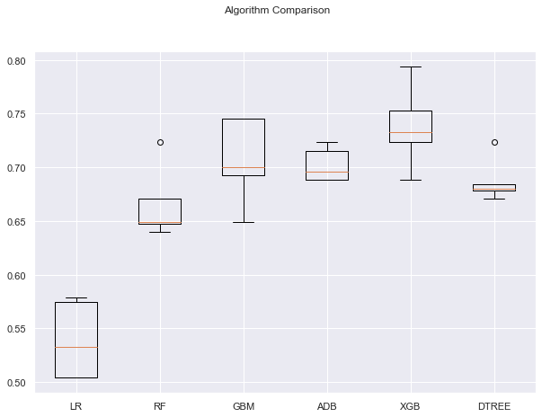

```python
# Plotting boxplots for CV scores of all models defined above
fig = plt.figure(figsize=(10, 7))

fig.suptitle("Algorithm Comparison")
ax = fig.add_subplot(111)

plt.boxplot(results)
ax.set_xticklabels(names)

plt.show()
```

## Hyperparameter Tuning

- We will use pipelines and tune the model using GridSearch and RandomSearch.
- Fist, let's create two functions to calculate different metrics and confusion matrix, so that we don't have to use the same code repeatedly for each model.

```python
##  Function to calculate different metric scores of the model - Accuracy, Recall and Precision
def get_metrics_score(model, flag=True):
    """
    model : classifier to predict values of X

    """
    # defining an empty list to store train and test results
    score_list = []

    pred_train = model.predict(X_train)
    pred_test = model.predict(X_test)

    train_acc = model.score(X_train, y_train)
    test_acc = model.score(X_test, y_test)

    train_recall = metrics.recall_score(y_train, pred_train)
    test_recall = metrics.recall_score(y_test, pred_test)

    train_precision = metrics.precision_score(y_train, pred_train)
    test_precision = metrics.precision_score(y_test, pred_test)

    score_list.extend(
        (
            train_acc,
            test_acc,
            train_recall,
            test_recall,
            train_precision,
            test_precision,
        )
    )

    # If the flag is set to True then only the following print statements will be dispayed. The default value is set to True.
    if flag == True:
        print("Accuracy on training set : ", model.score(X_train, y_train))
        print("Accuracy on test set : ", model.score(X_test, y_test))
        print("Recall on training set : ", metrics.recall_score(y_train, pred_train))
        print("Recall on test set : ", metrics.recall_score(y_test, pred_test))
        print(
            "Precision on training set : ", metrics.precision_score(y_train, pred_train)
        )
        print("Precision on test set : ", metrics.precision_score(y_test, pred_test))

    return score_list  # returning the list with train and test scores
```

```python
## Function to create confusion matrix
def make_confusion_matrix(model, y_actual, labels=[1, 0]):
    """
    model : classifier to predict values of X
    y_actual : ground truth

    """
    y_predict = model.predict(X_test)
    cm = metrics.confusion_matrix(y_actual, y_predict, labels=[0, 1])
    df_cm = pd.DataFrame(
        cm,
        index=[i for i in ["Actual - No", "Actual - Yes"]],
        columns=[i for i in ["Predicted - No", "Predicted - Yes"]],
    )
    group_counts = ["{0:0.0f}".format(value) for value in cm.flatten()]
    group_percentages = ["{0:.2%}".format(value) for value in cm.flatten() / np.sum(cm)]
    labels = [f"{v1}\n{v2}" for v1, v2 in zip(group_counts, group_percentages)]
    labels = np.asarray(labels).reshape(2, 2)
    plt.figure(figsize=(10, 7))
    sns.heatmap(df_cm, annot=labels, fmt="")
    plt.ylabel("True label")
    plt.xlabel("Predicted label")
```